### Introduction

The `rflot` package is an R interface to the [Flot](http://www.flotcharts.org/) JavaScript charting library. It is a *thin* wrapper, giving the [R] user unfettered access to the parameters of the JS library. It boasts the ability to display point, line, and bar charts and features:

- Configurable interactive features including tooltips, click handlers, as well as the ability to zoom-in on the same canvas
- Configurable axes and legends, including the ability to display data tied to multiple axes
- Ability to display grouped data
- Ability to easily produce plots in RStudio, RMarkdown or Shiny

#### Basic

Let us begin with a simple chart of ozone (in parts per billion) versus temperature. The function `flotChart` is used to specify the main data-source for the chart, as well as mannually adjust the height and width of the plot. It needs to be paired with the `flotSeries` function, which adds a layer/series to the chart.

```r
flotChart(airquality) %>%
  flotSeries(x=Temp,y=Ozone, label= '', points=list(show=T))
```

[interactive chart not shown]

#### Grouped Data

Next, let us make use of the `Month` column to group the data. The data is automatically colored by the group variable.

```r
flotChart(airquality) %>%
  flotSeries(x=Temp, y=Ozone, group = Month, label="Month: ", points=list(show=T))
```

[interactive chart not shown]

#### Multiple layers

We can add additional series to the chart by chaining additional calls to `flotSeries`.

```r
flotChart(airquality) %>%
  flotSeries(x=Temp, y=Ozone, group = Month, label="Month: ", points=list(show=T)) %>%
  flotSeries(x=seq(min(Temp), max(Temp), .1)
             ,y=predict(lm(Ozone ~ Temp + I(Temp^2) + I(Temp^3)), newdata = data.frame(Temp=seq(min(Temp), max(Temp), .1)))
             ,label="")
```

[interactive chart not shown]

#### Interactive Charts

```r
flotChart(airquality) %>%
  flotSeries(x=Temp, y=Ozone, group = Month, label="Month: ", extra.cols=list(Wind, Solar.R, Day), points=list(show=T), clickable=T, hoverable=T) %>%
  flotSeries(x=seq(min(Temp), max(Temp), .1)
             ,y=predict(lm(Ozone ~ Temp + I(Temp^2) + I(Temp^3)), newdata = data.frame(Temp=seq(min(Temp), max(Temp), .1)))
             ,label="") %>%
  flotOptions(selection=list(mode="xy")        #Enable zoom along both the the x- and y-axes
              ,tooltipOpts = list(             #Customize tool-tip options
                id = "customTip"
                ,content = htmlwidgets::JS("
                  function(label, xval, yval, flotItem) {
                    return 'Day: ' + flotItem.series.extra_data[flotItem.dataIndex][2] +
                            '<br>Solar.R: ' + flotItem.series.extra_data[flotItem.dataIndex][1] +
                            '<br>Wind: ' + flotItem.series.extra_data[flotItem.dataIndex][0];
                  }
                ")
                ,onHover = htmlwidgets::JS("
                  function(flotItem, el){
                    el.css('background-color', flotItem.series.color);
                  }")
                )
              ,onClick = htmlwidgets::JS("
                  function(event,pos,item) {
                    if(item) {
                      alert('You clicked on something');
                    }
                  }
                ")
              )
```

[interactive chart not shown]

#### Bar charts

In addition to point, and line charts, we can easily use this package to put together a bar chart. In the example below, we mark the x-axis data as cathegorical(can also be continuous)

```r
library(data.table)
flotChart(data.table(mtcars)[,list(count=.N),by=list(cyl)]) %>%
  flotSeries(x=cyl, y=count
             ,label= ''
             ,bars=list(show=T, barWidth= 0.6,align="center")) %>%
  flotOptions(yaxis=list(axisLabel='Count')
              ,xaxis=list(axisLabel="Number of Cylinders"
                ,mode="categories"
                ,tickLength= 0
              ))
```

[interactive chart not shown]

```r
flotChart(data.table(mtcars)[,list(count=.N),by=list(cyl)]) %>%
  flotSeries(x=cyl, y=count
             ,label= 'Total'
             ,hoverable = T
             ,bars=list(show=T, order = 1, barWidth= 0.3)) %>%
  flotSeries(data=data.table(mtcars)[,list(count=.N),by=list(cyl, gear)][order(cyl),], x=cyl, y=count, group=gear
            ,label= 'Count w/ Number of gears: '
            ,hoverable = T
            ,stack='gear'
            ,bars=list(show=T,  order=2, barWidth= 0.3)) %>%
  flotOptions(yaxis=list(axisLabel='Count')
              ,xaxis=list(axisLabel="Number of Cylinders"
                          ,mode="categories"
                          ,tickLength= 0
              )
              ,legend=list(position="nw"
                          ,backgroundColor='grey'
                          ,backgroundOpacity=.1))
```

[interactive chart not shown]

#### Time Series and Multiple Axes

Finally let us examine how you would go about charting a dual-axis time series. All dates must be passed in UTC * 1000 (milliseconds) format. We customize the axis labels, tick color and font color. In the chart below we consider the daily evolution of MSFT and AAPL stock prices starting in 2010.

```r
flotChart(read.csv("msft_aapl_stock_data.csv")) %>%
  flotSeries(x=as.numeric(as.POSIXct(date))*1000, y=msft, hoverable=T) %>%
  flotSeries(x=as.numeric(as.POSIXct(date))*1000, y=aapl, yaxis=2, color='red') %>%
  flotOptions(xaxis=list(axisLabel = 'Date', mode='time')
              ,yaxes=list(
                list(axisLabel='MSFT')
                ,list(axisLabel='AAPL', axisLabelUseCanvas=T, axisLabelColour='red', position= "right", color='red',tickColor='red', font=list(color='red')))
              ,selection=list(mode="x"))
```

[interactive chart not shown]

#### Using with Shiny and Including Additional Plug-ins

With `rflot` we have bundled a useful set of plug-ins that extend the functionality of Flot. However there are many other plug-ins you may wish to include in your app. You can do this easily by sourcing appropriate JS script.

This package exposes shiny output bindings that follow the standard shiny usage pattern. In particular to display the very first chart we examined via a shiny application, we pair the `flotOutput` function used in `ui.R`, with the `renderFlot` function in `server.R`. Moreover we include the symbols plugin, and use the `diamond` shape for the scatter plot.

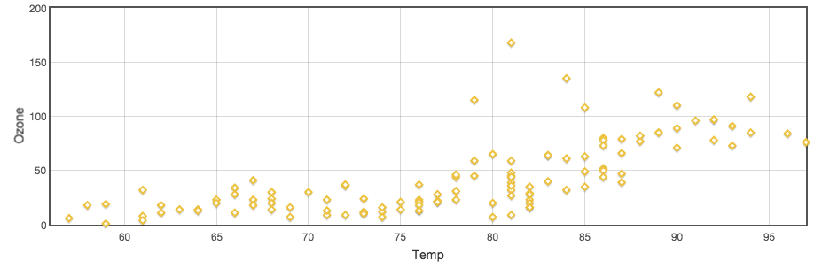

```r
library(shiny)
shinyApp(
  ui = fluidPage(
    tags$head(tags$script(type = 'text/javascript', src="http://cdn.rawgit.com/flot/flot/master/jquery.flot.symbol.js"))
    ,fluidRow(style = "padding-bottom: 20px;"
      ,column(12,
        flotOutput("flotGraph1", height=300)
      )
    )
  )
  ,server = function(input, output, session) {
    output$flotGraph1 <- renderFlot({
      flotChart(airquality) %>%
        flotSeries(x=Temp,y=Ozone, label= '', points=list(show=T, symbol='diamond'))
    })
  },
  options = list(height = 350)
)
```

### The JS API

Given that we have tried to keep the [R] code churn at a minimum, you may find yourself needing to inject snippets of JavaScript to achieve granular control over the various parameters of the Flot JS library (see examples above). Here are some useful references on underlying the options:

- [Flot API](https://github.com/flot/flot/blob/master/API.md)
- [Flot Tooltips](https://github.com/krzysu/flot.tooltip)
- [Flot Axis Labels](https://github.com/markrcote/flot-axislabels)